# V506 Lab 5

Data Reshape, Merges, and Hypothesis Testing

Luis Navarro

Fall 2024

# Readings for this lab

- [R Cookbook](https://rc2e.com/) Chapter 9.
- [R for Data Science](https://r4ds.had.co.nz/index.html) Chapter 5, 18, 19 (Complete)
- [The Epidemiologist R Handbook](https://epirhandbook.com/en/) Chapter 12, 14, 18, 20 (Complete).

# Setup: Clean Environment and Load Libraries

```r
# Clean the environment
rm(list=ls())

# Set your working directory
setwd("/Users/luisenriquenavarro/Library/CloudStorage/OneDrive-IndianaUniversity/V506/Fall24/Lab5")

# Packages Required for the session
library(pacman)
p_load(dplyr, ggplot2, rmarkdown, rio, here)
```

# Example: GDP States

- Sometimes data does not comes in the format we need it to work.
- To exemplify this, we use data from the Bureau of Economic Analysis on state’s Gross Domestic Product (GDP.)
- Get the data [here](https://www.bea.gov/data/gdp/gdp-state) or download it from Canvas.
- This data set has information on state’s GDP.
- Data: SAGDP9N: Real GDP by state: All industry total (Millions of chained 2012 dollars)

```r
gdp_states <- read.csv(file = "gdp_states.csv", header = TRUE) %>% tibble()
head(gdp_states)
```

```
## # A tibble: 6 × 28
##   GeoFips GeoName  X1997  X1998  X1999  X2000  X2001  X2002  X2003  X2004  X2005
##     <int> <chr>    <dbl>  <dbl>  <dbl>  <dbl>  <dbl>  <dbl>  <dbl>  <dbl>  <dbl>
## 1       0 United… 1.15e7 1.20e7 1.26e7 1.31e7 1.33e7 1.35e7 1.39e7 1.44e7 1.49e7
## 2    1000 Alabama 1.45e5 1.50e5 1.55e5 1.57e5 1.57e5 1.60e5 1.65e5 1.77e5 1.84e5
## 3    2000 Alaska  4.22e4 4.11e4 4.06e4 3.94e4 4.10e4 4.30e4 4.24e4 4.41e4 4.57e4
## 4    4000 Arizona 1.68e5 1.83e5 1.99e5 2.08e5 2.13e5 2.21e5 2.34e5 2.44e5 2.62e5
## 5    5000 Arkans… 8.26e4 8.46e4 8.91e4 8.99e4 8.98e4 9.30e4 9.69e4 1.02e5 1.06e5
## 6    6000 Califo… 1.38e6 1.47e6 1.57e6 1.70e6 1.69e6 1.72e6 1.79e6 1.85e6 1.93e6
## # ℹ 17 more variables: X2006 <dbl>, X2007 <dbl>, X2008 <dbl>, X2009 <dbl>,
## #   X2010 <dbl>, X2011 <dbl>, X2012 <dbl>, X2013 <dbl>, X2014 <dbl>,
## #   X2015 <dbl>, X2016 <dbl>, X2017 <dbl>, X2018 <dbl>, X2019 <dbl>,
## #   X2020 <dbl>, X2021 <dbl>, X2022 <dbl>
```

# Data Formats: Wide and Long

- Data could be presented in one of two formats.
- Long vs wide format.
- **Wide Format:** contains values that do not repeat on the first column.

```r
gdp_wide %>% head(n = 10)
```

```
## # A tibble: 10 × 28
##    GeoFips GeoName        X1997  X1998  X1999  X2000  X2001  X2002  X2003  X2004
##      <int> <chr>          <dbl>  <dbl>  <dbl>  <dbl>  <dbl>  <dbl>  <dbl>  <dbl>
##  1       0 United States 1.15e7 1.20e7 1.26e7 1.31e7 1.33e7 1.35e7 1.39e7 1.44e7
##  2    1000 Alabama       1.45e5 1.50e5 1.55e5 1.57e5 1.57e5 1.60e5 1.65e5 1.77e5
##  3    2000 Alaska        4.22e4 4.11e4 4.06e4 3.94e4 4.10e4 4.30e4 4.24e4 4.41e4
##  4    4000 Arizona       1.68e5 1.83e5 1.99e5 2.08e5 2.13e5 2.21e5 2.34e5 2.44e5
##  5    5000 Arkansas      8.26e4 8.46e4 8.91e4 8.99e4 8.98e4 9.30e4 9.69e4 1.02e5
##  6    6000 California    1.38e6 1.47e6 1.57e6 1.70e6 1.69e6 1.72e6 1.79e6 1.85e6
##  7    8000 Colorado      1.84e5 2.01e5 2.15e5 2.32e5 2.35e5 2.35e5 2.38e5 2.41e5
##  8    9000 Connecticut   1.91e5 1.96e5 2.02e5 2.16e5 2.18e5 2.17e5 2.19e5 2.33e5
##  9   10000 Delaware      4.60e4 5.04e4 5.42e4 5.66e4 5.84e4 5.65e4 5.73e4 6.01e4
## 10   11000 District of … 7.98e4 8.12e4 8.48e4 8.54e4 8.84e4 9.11e4 9.29e4 9.75e4
## # ℹ 18 more variables: X2005 <dbl>, X2006 <dbl>, X2007 <dbl>, X2008 <dbl>,
## #   X2009 <dbl>, X2010 <dbl>, X2011 <dbl>, X2012 <dbl>, X2013 <dbl>,
## #   X2014 <dbl>, X2015 <dbl>, X2016 <dbl>, X2017 <dbl>, X2018 <dbl>,
## #   X2019 <dbl>, X2020 <dbl>, X2021 <dbl>, X2022 <dbl>
```

- **Long Format:** contains values that do repeat on the first column.

```r
gdp_long %>% head(n = 15)
```

```
## # A tibble: 15 × 4
##    GeoFips GeoName              year   real_gdp
##      <int> <chr>                <chr>     <dbl>
##  1       0 United States        X1997 11529157
##  2    1000 Alabama              X1997   144501.
##  3    2000 Alaska               X1997    42211.
##  4    4000 Arizona              X1997   168409.
##  5    5000 Arkansas             X1997    82571.
##  6    6000 California           X1997  1378276.
##  7    8000 Colorado             X1997   184185.
##  8    9000 Connecticut          X1997   190519.
##  9   10000 Delaware             X1997    45980.
## 10   11000 District of Columbia X1997    79828.
## 11   12000 Florida              X1997   559805.
## 12   13000 Georgia              X1997   328119.
## 13   15000 Hawaii               X1997    55804.
## 14   16000 Idaho                X1997    36997.
## 15   17000 Illinois             X1997   576730.
```

# Reshape data with dplyr: gather and spread

- To reshape the data set we use the functions *gather* and *spread*.
- **gather:** from wide to long (pivot_longer)
- **spread:** from long to wide (pivot_wider)
- Both the gather and spread functions will create a new data frame, so we need to specify the names of the new variables.
- Syntax *gather* function.

```r
gather(data,
       key = "key", ## New Column Created
       value = "value", ## Values
       -..., ## selection of columns that identify observations in the data
       )
```

- gather general syntax: notice the columns (pivots) need to be specified by using the “-” symbol

```r
df_long <- df %>%
  gather(key = "variable",
         value = "level", -id)
```

- Syntax *spread* function

```r
spread(data,
       key = "key", ## name of the variable that will be the columns
       value = "value", ## Values it takes
       )
```

- Notice that the spread function does not requires the selection of columns that identify observations in the data .
- Why? Once you determined the key and value, then the rest of the variables identify each unique observation in the data.

# Example: Reshape GDP data

- Let’s express the GDP data on long format.

```r
gdp_long <- gdp_states %>%
  gather(key = "year", value = "real_gdp", -c(GeoName,GeoFips)) %>%
   ## Intermediate Step to clean year variable
  mutate(year = substr(year,2,nchar(year)) %>% as.double()) %>%
  # Keep only states data
  filter(GeoFips >0 &GeoFips < 90000) %>%
  # Rename variables
  rename(state = GeoName)
```

- With the data in this format now we can easily compare states GDP.
- Now let’s do an example of reshape wide

```r
gdp_wide <- gdp_long %>%
  spread(key = year, # name of the variable that will be columns
         value = real_gdp)

gdp_wide %>% head()
```

```
## # A tibble: 6 × 28
##   GeoFips state   `1997` `1998` `1999` `2000` `2001` `2002` `2003` `2004` `2005`
##     <int> <chr>    <dbl>  <dbl>  <dbl>  <dbl>  <dbl>  <dbl>  <dbl>  <dbl>  <dbl>
## 1    1000 Alabama 1.45e5 1.50e5 1.55e5 1.57e5 1.57e5 1.60e5 1.65e5 1.77e5 1.84e5
## 2    2000 Alaska  4.22e4 4.11e4 4.06e4 3.94e4 4.10e4 4.30e4 4.24e4 4.41e4 4.57e4
## 3    4000 Arizona 1.68e5 1.83e5 1.99e5 2.08e5 2.13e5 2.21e5 2.34e5 2.44e5 2.62e5
## 4    5000 Arkans… 8.26e4 8.46e4 8.91e4 8.99e4 8.98e4 9.30e4 9.69e4 1.02e5 1.06e5
## 5    6000 Califo… 1.38e6 1.47e6 1.57e6 1.70e6 1.69e6 1.72e6 1.79e6 1.85e6 1.93e6
## 6    8000 Colora… 1.84e5 2.01e5 2.15e5 2.32e5 2.35e5 2.35e5 2.38e5 2.41e5 2.52e5
## # ℹ 17 more variables: `2006` <dbl>, `2007` <dbl>, `2008` <dbl>, `2009` <dbl>,
## #   `2010` <dbl>, `2011` <dbl>, `2012` <dbl>, `2013` <dbl>, `2014` <dbl>,
## #   `2015` <dbl>, `2016` <dbl>, `2017` <dbl>, `2018` <dbl>, `2019` <dbl>,
## #   `2020` <dbl>, `2021` <dbl>, `2022` <dbl>
```

# Data Merging

- Sometimes you need to merge datasets for your analysis.
- Say you want to compute GDP per capita. That is, GDP divided by population.
- We need to add a column with the population.

```r
states_pop_long <- rio::import(file = "state_population_long.csv", header = TRUE) %>% tibble() %>% select(-V1)
head(states_pop_long)
```

```
## # A tibble: 6 × 3
##   state       year population
##   <chr>      <int>      <int>
## 1 Alabama     2020    5031864
## 2 Alaska      2020     732964
## 3 Arizona     2020    7186683
## 4 Arkansas    2020    3014348
## 5 California  2020   39503200
## 6 Colorado    2020    5785219
```

```r
# Define data for merge
gdp_long2020 <- gdp_long %>%
  filter(year >= 2020)
```

# Left Join

```r
# syntax code
merged_data1 <- data_x %>%
  left_join(data_y, by = c("var1", ..., "var2"),
            relationship = "one-to-one")


merged_data2 <- data_x %>%
  left_join(data_y, by = c("var1"),
            relationship = "many-to-one") # Many observations in x, will receive the same value of y
```

# Example

```r
states_data <- gdp_long2020 %>%
  # Merge population data
  left_join(states_pop_long,
            by = c("state", "year"), #merge by state and year
            relationship = "one-to-one")
```

- Compute GDP per capita with the population data.

```r
states_data <- states_data %>%
  # multiply by one million, to express everything in US dollars.
  mutate(gdp_per_capita = 1000000*real_gdp/population)

states_data %>% head()
```

```
## # A tibble: 6 × 6
##   GeoFips state       year real_gdp population gdp_per_capita
##     <int> <chr>      <dbl>    <dbl>      <int>          <dbl>
## 1    1000 Alabama     2020  199881.    5031864         39723.
## 2    2000 Alaska      2020   50705.     732964         69178.
## 3    4000 Arizona     2020  327178     7186683         45526.
## 4    5000 Arkansas    2020  117268.    3014348         38903.
## 5    6000 California  2020 2667221.   39503200         67519.
## 6    8000 Colorado    2020  353345.    5785219         61077.
```

- Extra: compute the average GDP per capita for each year.

```r
states_data %>%
  # Compute the average across states, to get observations for each year
  group_by(year) %>%
  summarize(gdp_per_capita = mean(gdp_per_capita, na.rm = TRUE))
```

```
## # A tibble: 3 × 2
##    year gdp_per_capita
##   <dbl>          <dbl>
## 1  2020         54757.
## 2  2021         57300.
## 3  2022         58026.
```

# Statistical Inference and Hypothesis Testing

- Take the star wars data.

```r
starwars <- dplyr::starwars
# the function pull from dplyr is equivalent to the dollar sign.
# starwars %>% pull(mass) is the same as writing starwars$mass
mass_sw <- starwars %>% pull(mass)
```

- Suppose we are interested on calculating the average mass of star wars characters.
- We do it directly with the mean function.
- **Point Estimate:** 97.31 kgs.

```r
mean(mass_sw, na.rm = TRUE)
```

```
## [1] 97.31186
```

- How can we know how reliable is this estimation? How likely is that if we take another sample from the universe of star wars characters that we get a similar estimate for the average mass?
- **Central Limit Theorem** If $N$ is large enough, the statistic $\bar{x}$ follows a normal distribution with mean $\mu$ and standard deviation $\sigma$, where $\mu$ and $\sigma$ are the mean and standard deviation of the distribution where the sample comes from.
- To assess the sampling variation of the estimate we compute the standard errors.
- With the standard errors we can construct confidence intervals by calculating margin of errors.
- **Margin of Error**

$$\begin{equation}
ME = z^* \times SE(\bar{x})
\end{equation}$$

Where $z^*$ is percentile of the normal distribution correspondent to the confidence level chose for the interval.

To understand intuitively the percentile recall the definition. Let $Z$ be a standard normal random variable.

$$\begin{equation}
1-\alpha = Pr(-z^* < Z < z^*)
\end{equation}$$

Then, the definition of **Confidence Interval**

$$\begin{equation}
CI = (\bar{x} - M.E, \bar{x} + M.E)
\end{equation}$$

Let’s look at data. First, at the distribution of a standard normal random variable.

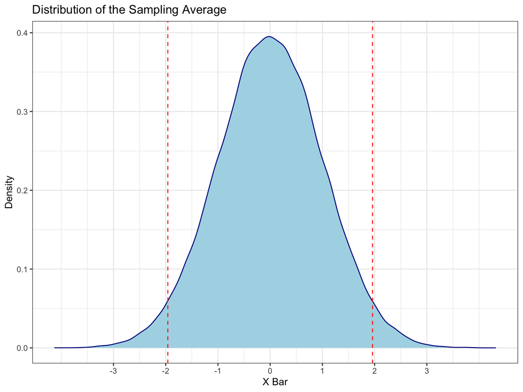

```r
set.seed(123)
n_samples <- 100000  # Number of random samples to generate
data <- data.frame(x = rnorm(n_samples))
lower_value <- qnorm(0.025, mean = 0, sd =1, lower.tail = TRUE)
upper_value <- qnorm(0.975, mean = 0, sd =1, lower.tail = TRUE)

## Ggplot
xbar_dist <- ggplot(data, aes(x = x)) +
             geom_density(color = "darkblue", fill = "lightblue") +
             geom_vline(xintercept = c(lower_value, upper_value), color = "red", linetype = "dashed")+
             theme_bw() +
             labs(title = "Distribution of the Sampling Average", x = "X Bar",y = "Density") +
             scale_x_continuous(breaks = -3:3)
xbar_dist
```

# Statistical Inference: Example

Let’s compute the mean, standard deviation, standard error, margin of error, and confidence interval for the sample mean of variable mass.

```r
mean_inference <- starwars %>%
  # use summarize to compute mean, sd and number of obs
  summarize(mean = mean(mass, na.rm = TRUE),
            sd = sd(mass, na.rm = TRUE),
            obs = n()) %>%
  # compute manually the standard error, margin of error, and confidence intervals
  mutate(
    std.error = sd/sqrt(obs),
    margin.error = std.error*qnorm(0.975),
    conf.low = mean - margin.error,
    conf.upp = mean + margin.error
  ) %>%
  # create a sentence that has the confidence interval as a character
  mutate(
    conf.int = paste("(",round(conf.low,4),",", round(conf.upp,4),")", sep = '')
  )

# show the data frame transposed
mean_inference %>% t()
```

```
##              [,1]
## mean         "97.31186"
## sd           "169.4572"
## obs          "87"
## std.error    "18.16771"
## margin.error "35.60807"
## conf.low     "61.7038"
## conf.upp     "132.9199"
## conf.int     "(61.7038,132.9199)"
```

```r
test<-t.test(mass_sw, mu = 0)
test$conf.int
```

```
## [1]  53.15109 141.47264
## attr(,"conf.level")
## [1] 0.95
```

```r
#Define the Statistics
mass_mean <-mean(mass_sw, na.rm = TRUE)
mass_sd <-sd(mass_sw, na.rm = TRUE)
mass_obs <- mass_sw %>% na.omit() %>% length()
mass_se <- mass_sd / sqrt(mass_obs)
# Compute the Margin Error
margin_error <- mass_se*upper_value
# Compute the Confidence Interval
ci <- c(mass_mean - margin_error, mass_mean + margin_error)
ci <- paste("(",as.character(round(ci[1],4)),",",as.character(round(ci[2],4)), ")", sep="")
# Display Results
data.frame(mean = mass_mean, se = mass_se, confint = ci) %>% t()
```

```
##         [,1]
## mean    "97.31186"
## se      "22.06144"
## confint "(54.0722,140.5515)"
```

# Hypothesis Testing: T-test

Test Stat
$$\begin{equation}
t = \frac{\bar{x} - \mu}{SE(\bar{x})}
\end{equation}$$

- How does the test works? Compute the sampling distribution of the test-statistic under the null-hypothesis.
- Under the null hypothesis, the statistic is distributed normal with mean 0 and standard deviation.
- Test how likely was your draw under the null distribution.

```r
# Run the Test with R command
mu_null <- 50
test <- t.test(starwars$mass, mu=mu_null)
degfree <- test$parameter
test
```

```
##
##  One Sample t-test
##
## data:  starwars$mass
## t = 2.1445, df = 58, p-value = 0.03619
## alternative hypothesis: true mean is not equal to 50
## 95 percent confidence interval:
##   53.15109 141.47264
## sample estimates:
## mean of x
##  97.31186
```

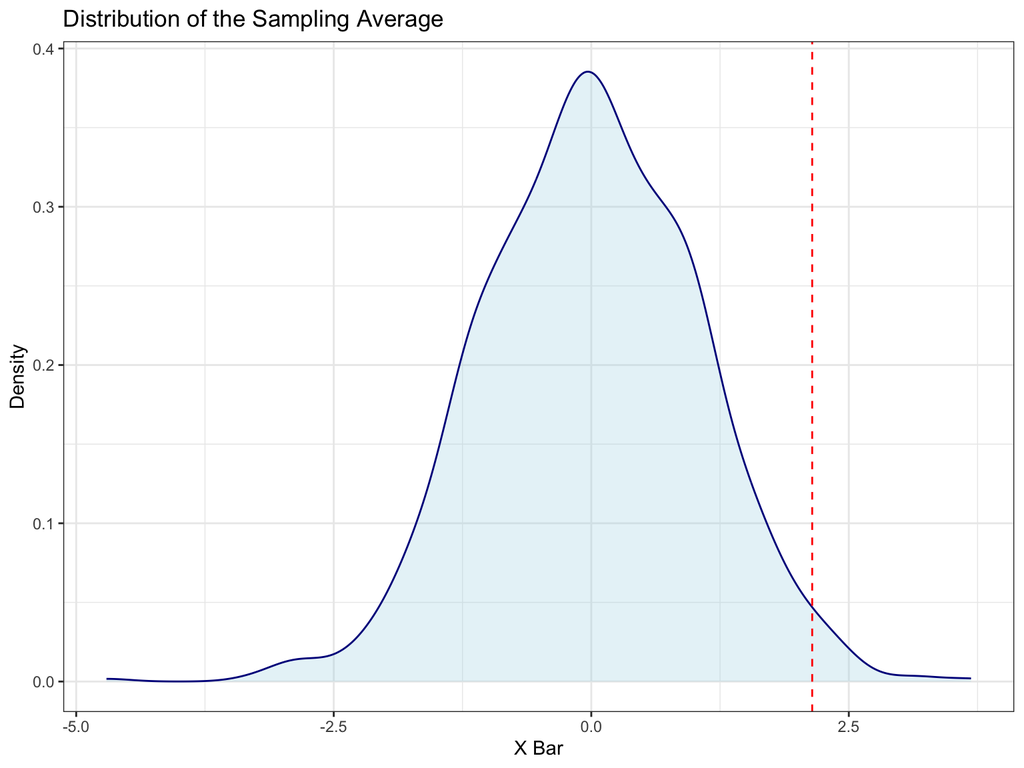

```r
# Compute the Test Statistic
t_stat <- (mass_mean - mu_null)/mass_se
# Compute the distribution of test-stastic under the null
t_dist_null <- data.frame(x = rt(n=1000, df =degfree)) %>% tibble()

## Ggplot
t_dist_plot <- ggplot(t_dist_null, aes(x = x)) +
             geom_density(color = "darkblue", fill = "lightblue", alpha = 0.3) +
             geom_vline(xintercept = t_stat, color = "red", linetype = "dashed")+
             theme_bw() +
             labs(title = "Distribution of the Sampling Average", x = "X Bar",y = "Density")
t_dist_plot
```

# Two Sample t-test

- **Two Sample T-test:** method used to test whether the unknown population means of two groups are equal or not.
- Suppose we have two random variables coming from a normal distribution.
- Variable X comes from a normal(0,1) and variable Y comes from a normal(0.5, 1)

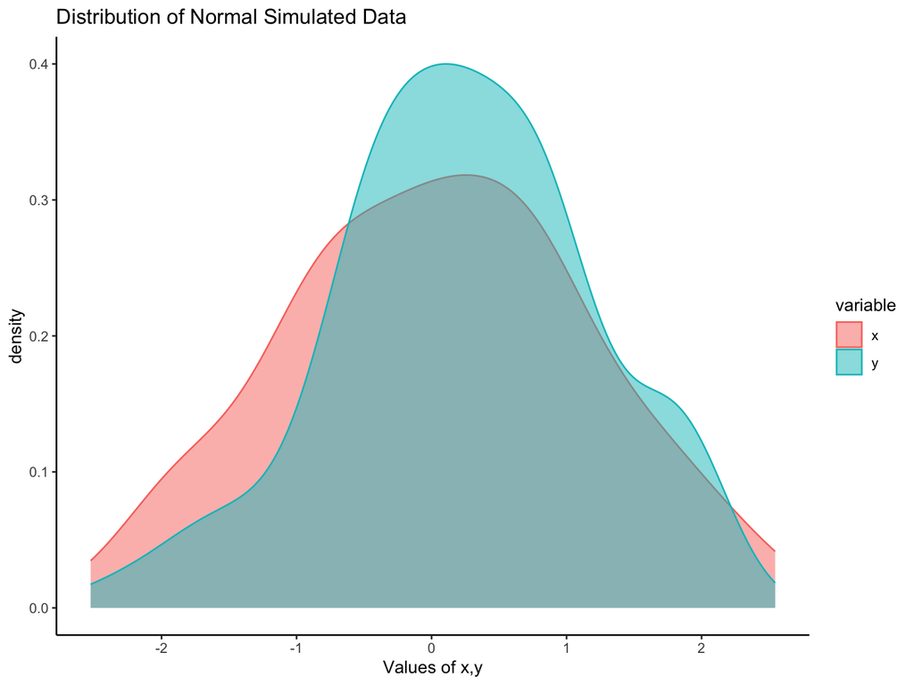

```r
# simulate data
obs = 100
simulated_normal_data <- data.frame(id = 1:obs,
                               x = rnorm(obs, mean = 0, sd = 1),
                               y = rnorm(obs, mean = 0.5, sd = 1))

# visualize data
simulated_normal_data %>%
  # reshape data long to use exploit ggplot grammar
  gather(key = "variable", value = "value", -id) %>%
  ggplot(mapping = aes(x = value, color = variable, fill = variable)) +
  # geom_density allows you to draw the kernel density of the simulated data
  geom_density(alpha = 0.5) +
  labs(x = "Values of x,y", y = "density",
       title = "Distribution of Normal Simulated Data") +
  scale_x_continuous(breaks = -3:4) +
  theme_classic()
```

- Test the hypothesis that the sample mean of x is equal to the sample mean of y.
- **Null Hypothesis**:
  $$H_0: \bar{x} - \bar{y} = 0$$
- **Alternative Hypothesis**
  $$HA: \bar{x} - \bar{y} \neq 0$$
- **Hypothesis Testing**: t.test performs t-tests on vectors of data.

```r
vector_x <- simulated_normal_data$x
vector_y <- simulated_normal_data$y

two_sample_test <- t.test(vector_x, vector_y)
two_sample_test
```

```
##
##  Welch Two Sample t-test
##
## data:  vector_x and vector_y
## t = -1.3034, df = 193.21, p-value = 0.194
## alternative hypothesis: true difference in means is not equal to 0
## 95 percent confidence interval:
##  -0.48075552  0.09817514
## sample estimates:
##  mean of x  mean of y
## 0.04380166 0.23509185
```

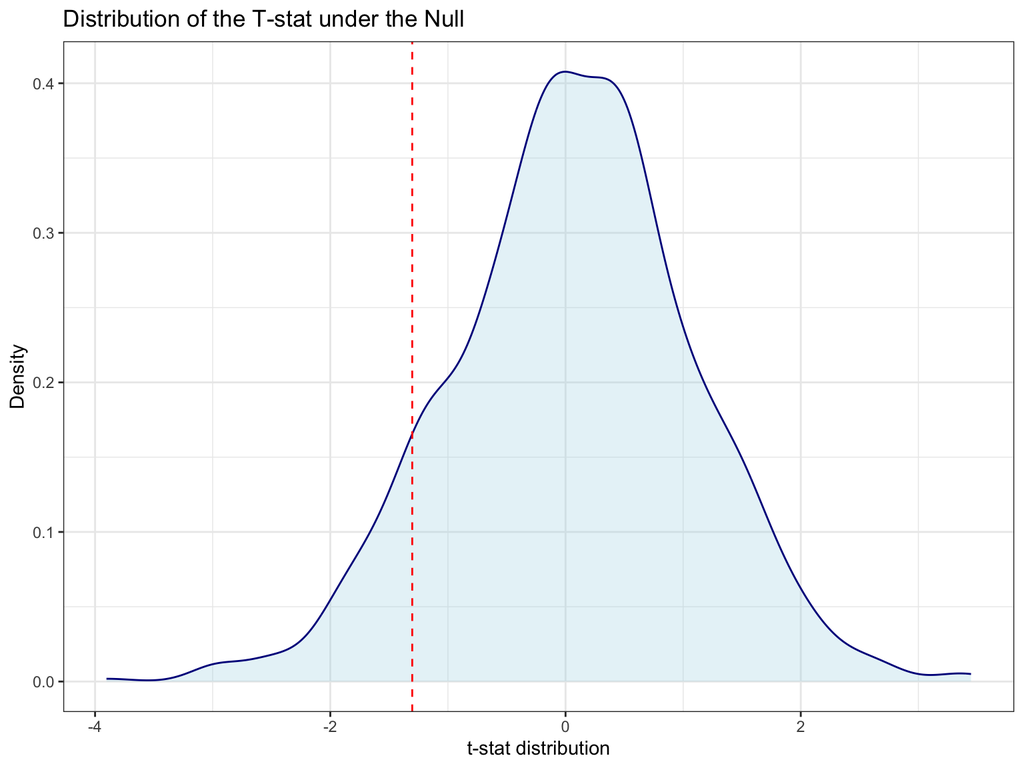

```r
# visual representation of the two sample t-test
degfree = two_sample_test$parameter
t_stat = two_sample_test$statistic
# Compute the distribution of test-stastic under the null
t_dist_null <- data.frame(x = rt(n=1000, df =degfree)) %>% tibble()

## Ggplot
t_dist_plot <- ggplot(t_dist_null, aes(x = x)) +
             geom_density(color = "darkblue", fill = "lightblue", alpha = 0.3) +
             geom_vline(xintercept = t_stat, color = "red", linetype = "dashed")+
             theme_bw() +
             labs(title = "Distribution of the T-stat under the Null", x = "t-stat distribution",y = "Density")
t_dist_plot
```

# Hypothesis Testing: Prop-test

- Suppose we have data coming from two different coins (distributions)
- **Coin 1:** fair coin (i.e. $Pr(Heads) =0.5$)
- **Coin 2:** unfair coin (i.e. $Pr(Heads) =0.3$)
- Most of the times the data generating process is not observable.
- In other words: you don’t know from which experiment (distribution) you are drawing samples from.
- Suppose you got the data from both experiments but you don’t know whether the coins generating the outcomes are the same or different.
- **prop.test** can be used for testing the null that the proportions (probabilities of success) in several groups are the same, or that they equal certain given values.

$$\begin{equation*}
\hat{p} = \frac{Successes}{Trials}
\end{equation*}$$

- Let’s simulate the outcome of 100 coin-toss.
- **First Experiment:** 100 draws from Coin 1.
- **Second Experiment:** 100 draws from Coin 2.
- We can directly compute the (observed) percentage of heads (successes) for each coin.

```r
toss1 <- rbinom(n=100, size = 1, p = 0.5)
toss2 <- rbinom(n=100, size = 1, p = 0.3)
trials <- rep(1,100)
exp_res <- data.frame(exp1 = mean(toss1), exp2 = mean(toss2)) %>% tibble()
head(exp_res)
```

```
## # A tibble: 1 × 2
##    exp1  exp2
##   <dbl> <dbl>
## 1  0.48  0.26
```

- **Null Hypothesis** $H_0$ :The two populations (i.e. outcomes from each coin) have the same proportion of heads.
  $$\begin{equation*}
  H_0: \hat{p}_0 = \hat{p}_1
  \end{equation*}$$
- **Alternative Hypothesis** $H_A$: The proportion of heads is different in at least one of the populations.
  $$\begin{equation*}
  H_0: \hat{p}_0 \neq \hat{p}_1
  \end{equation*}$$
- **Hypothesis Testing**: prop.test() is used for testing the null that the proportions are the same.

```r
prop1 <- mean(toss1)*100
prop2 <- mean(toss2)*100
tot_trials <- mean(trials)*100
data.frame(exp1 = prop1, exp2 = prop2) %>% t()
```

```
##      [,1]
## exp1   48
## exp2   26
```

Let’s use the *prop.test* function to compute the test.

```r
prop.test(x = c(prop1,prop2), n = c(tot_trials,tot_trials))
```

```
##
##  2-sample test for equality of proportions with continuity correction
##
## data:  c(prop1, prop2) out of c(tot_trials, tot_trials)
## X-squared = 9.4595, df = 1, p-value = 0.002101
## alternative hypothesis: two.sided
## 95 percent confidence interval:
##  0.07969556 0.36030444
## sample estimates:
## prop 1 prop 2
##   0.48   0.26
```

- **Interpretation**: with p-value $<$ 0.05 we reject the null hypothesis that the proportions of both groups are the same.

# Extra: States GDP Graph

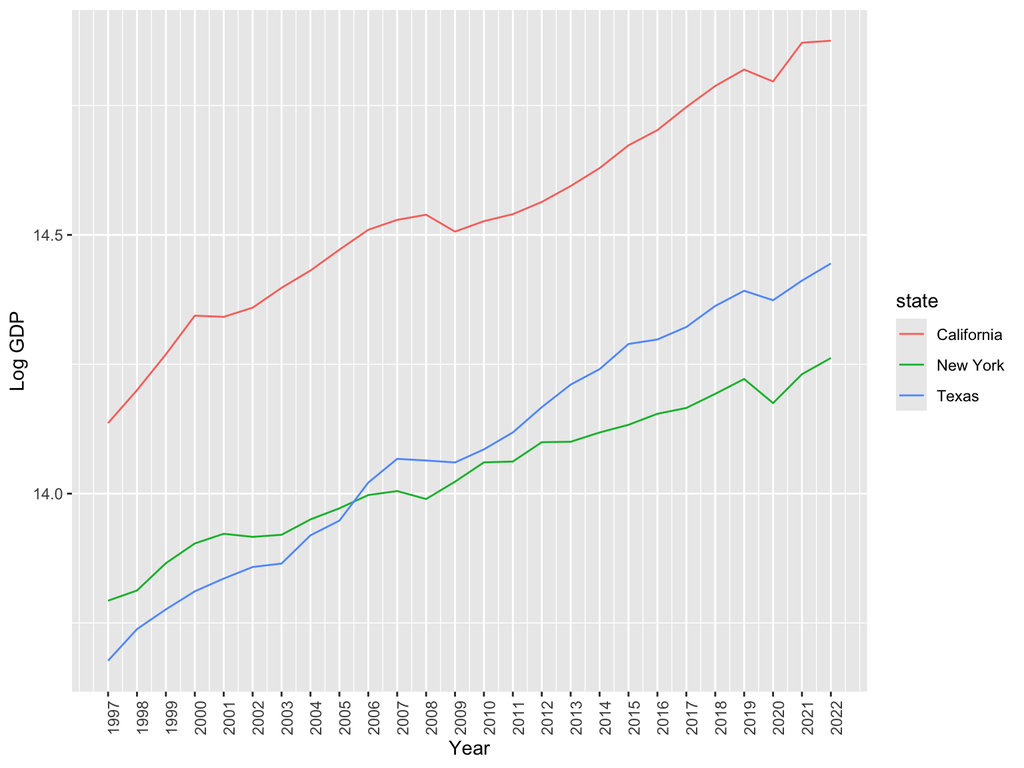

```r
gdp_graph <- gdp_long %>%
  # Filter some states to show
  filter(state == "California" | state == "Texas" | state == "New York") %>%
  # Create log gdp variable to ease comparison
  mutate(log_gdp = log(real_gdp)) %>%
  ggplot(mapping = aes(x = year, y = log_gdp,
                       col = state)) +   # Each state gets an individual color
  geom_line() +  # Draw a line plot
  labs(x = "Year", y = "Log GDP") +
  scale_x_continuous(breaks = 1997:2022) +
  theme(axis.text.x.bottom = element_text(angle = 90))


gdp_graph
```

- *Quick Tip:* functions allow you to automatize processes. A useful one is formatting your graphs.

```r
# Function that allows you to format all your plots
# Define Fontsize outside the function (you can plug it as an addtional parameter if you like)
fontsize = 12
# Function:
format_plot <- function(graph, title, subtitle){
  # Format the Graph
  formatted_plot <- graph  +
           theme_bw() +
           labs(title = title,
                subtitle = subtitle) +
           scale_y_continuous(n.breaks=10) +
           theme(axis.text.x = element_text(angle = 90, size = fontsize),
                 axis.text.y = element_text(angle = 0, size = fontsize),
                 axis.title.x = element_text(size = fontsize),
                 axis.title.y = element_text(size = fontsize),
                 legend.text = element_text(size = fontsize -2),
                 legend.title = element_blank(),
                 plot.title = element_text(angle = 0, size = fontsize + 3, face = "bold"))

  return(formatted_plot)
}
```

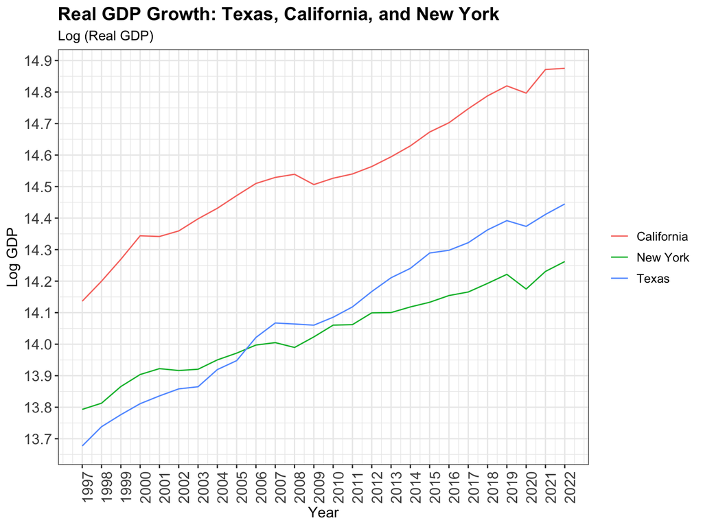

```r
# show formatted plot
format_plot(graph = gdp_graph,
            title = "Real GDP Growth: Texas, California, and New York",
            subtitle = "Log (Real GDP)")
```

# Extra Example: Merge using base R

- merge() allows you to combine to data frames using common colums or row names–to join two separate data frames.
- merge(x,y,…)– the data frames you’d like to merge.
- You also specify “by”. This can be “by.x=”, “by.y=”, or “by=” to specify what you are going to be matching on.
- “all=” allows you to specify if you want to merge all observations of each data frame.

**Example:** Let’s create some fake data that we can use:

```r
income_df = tibble(id = c(1:100),
                   urban = sample(c(0,1), replace=TRUE, size=100),
                   income = sample(c(0, 20000:100000), replace=TRUE, size=100))

income_df <- income_df %>% arrange(by_group=-id)

health_df = tibble(id = c(1:100),
                  health_spending  = sample(c(0:20000), replace=TRUE, size=100))
```

- sample() takes a sample of the specified size (size=n) from the elements in x with or without replacement.
- I wanted to randomly assign (0 and 1) as a binary variable to be if the person lives in an urban area or not.
- Notice that both data frames have a common variable, *id*.

# Extra Example: Merge using base R

```r
df1 = merge(income_df, health_df, by="id")
head(df1)
```

```
##   id urban income health_spending
## 1  1     1  56025           14015
## 2  2     0  51664           11676
## 3  3     0  46519            6420
## 4  4     0  61794           18261
## 5  5     1  82394            3593
## 6  6     1  25083            6563
```

- Now suppose there is a data frame that only has data for the first 30 observations and has a dummy variable if they had an ER visit:

```r
er_visits = tibble(id = c(1:30), er_visit = sample(c(1,0), replace=TRUE, size=30))
er_visits
```

```
## # A tibble: 30 × 2
##       id er_visit
##    <int>    <dbl>
##  1     1        1
##  2     2        0
##  3     3        1
##  4     4        1
##  5     5        0
##  6     6        0
##  7     7        1
##  8     8        0
##  9     9        0
## 10    10        1
## # ℹ 20 more rows
```

- Merge to *er_visits* to *df1*:

```r
df2 = merge(df1, er_visits, by = "id")
head(df2, n=10L)
```

```
##    id urban income health_spending er_visit
## 1   1     1  56025           14015        1
## 2   2     0  51664           11676        0
## 3   3     0  46519            6420        1
## 4   4     0  61794           18261        1
## 5   5     1  82394            3593        0
## 6   6     1  25083            6563        0
## 7   7     0  60496            1674        1
## 8   8     1  62981            9277        0
## 9   9     1  54795           10773        0
## 10 10     0  96994             379        1
```

```r
nrow(df2)
```

```
## [1] 30
```

- Notice that *df2* has only 30 observations, so *merge()* restricted the sample to the first 30 id’s with ER information.
- We can force it to merge on *all* (all observations from both datasets):

```r
df3 = merge(df1, er_visits, by = "id", all = TRUE)
```

- Or merge on *all.x* (Keep all observations from data frame x):

```r
df4 = merge(df1, er_visits, by="id", all.x = TRUE)
```

- Or merge on *all.y* (Keep all observations from data frame y):

```r
df5 = merge(df1, er_visits, by="id", all.y = TRUE)
```